# Lesson 3 Solution

Daniel Baller

1/10/2022

## R Markdown overview.

- Three elements to a markdown document
- Good habits for coding
- Naming code Chunks
- Don’t alter raw data
- Hard code only when necessary
- Text formatting
- Visual editor

For more info on using R markdown check out the slides [HERE](https://danielpballer.github.io/Rmarkdown_and_GitHub_Class/#1)

or the R Markdown Cheat sheet in the files of our teams page.

## Compiling a .Rmd file

```r
library(Lahman)
library(tidyverse)
library(knitr)
```

# Chapter 2 Intro to R

Tidyverse Verbs (pg 35)

- `select()`
- `filter()`
- `group_by()`
- `mutate()`
- `summarize()`
- `arrange()`

Let’s investigate how home run rates in Major League Baseball have changed over time. The R Lahman package imports data from Sean Lahman’s Baseball Archive. In this example, we will use the Batting data frame in the package.

First let’s explore what data we can pull from the Batting dataframe

```r
# Batting data frame contains one line per player per season per stint
# Here are players with the most home runs in a season
Batting %>%
  select(playerID, yearID, stint, lgID, HR, AB) %>%
  arrange(-HR) %>%
  head(10) %>%
  kable()
```

| playerID | yearID | stint | lgID | HR | AB |
| --- | --- | --- | --- | --- | --- |
| bondsba01 | 2001 | 1 | NL | 73 | 476 |
| mcgwima01 | 1998 | 1 | NL | 70 | 509 |
| sosasa01 | 1998 | 1 | NL | 66 | 643 |
| mcgwima01 | 1999 | 1 | NL | 65 | 521 |
| sosasa01 | 2001 | 1 | NL | 64 | 577 |
| sosasa01 | 1999 | 1 | NL | 63 | 625 |
| marisro01 | 1961 | 1 | AL | 61 | 590 |
| ruthba01 | 1927 | 1 | AL | 60 | 540 |
| ruthba01 | 1921 | 1 | AL | 59 | 540 |
| stantmi03 | 2017 | 1 | NL | 59 | 597 |

Steps to this coding task:

1. Include only players in Major League Baseball
2. Calculate the total number of home runs (HR) and at bats (AB) each season
3. Calculate the home run rate each season

```r
# calculate the home run rate for each season
homeRuns <- Batting %>%
  filter(lgID %in% c("AL","NL")) %>%
  group_by(yearID) %>%
  summarize(HR = sum(HR),
            AB = sum(AB)) %>%
  mutate(rate = HR/AB)

homeRuns %>%
  head(10) %>%
  kable()
```

| yearID | HR | AB | rate |
| --- | --- | --- | --- |
| 1876 | 40 | 20121 | 0.0019880 |
| 1877 | 24 | 13667 | 0.0017561 |
| 1878 | 23 | 13644 | 0.0016857 |
| 1879 | 58 | 24155 | 0.0024012 |
| 1880 | 62 | 24301 | 0.0025513 |
| 1881 | 76 | 24377 | 0.0031177 |
| 1882 | 126 | 24769 | 0.0050870 |
| 1883 | 124 | 29012 | 0.0042741 |
| 1884 | 321 | 32687 | 0.0098204 |
| 1885 | 174 | 31123 | 0.0055907 |

Let’s look at a plot

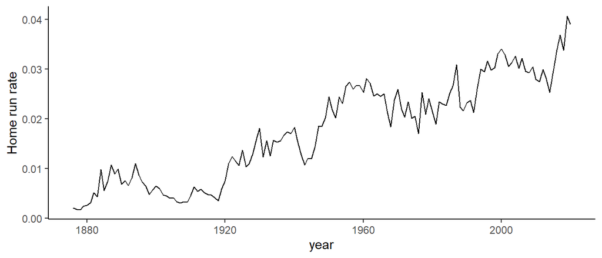

Home run rate in Major League Baseball by year.

```r
homeRuns %>%
  ggplot(aes(x = yearID, y = rate)) +
  geom_line() +
  labs(x = "year",
       y = "Home run rate")+
  theme_classic()
```

- Use R to find career batting average (H/AB) leaders of your favorite team. More specifically, select a team and report a table of the 10 players with at least 2500 at bats (AB) with the highest batting averages while playing for that team.

Mariners career batting average leaders.

| playerID | H | AB | AVG |
| --- | --- | --- | --- |
| suzukic01 | 2542 | 7907 | 0.321 |
| martied01 | 2247 | 7213 | 0.312 |
| rodrial01 | 966 | 3126 | 0.309 |
| canoro01 | 821 | 2776 | 0.296 |
| griffke02 | 1843 | 6317 | 0.292 |
| davisal01 | 1163 | 4136 | 0.281 |
| ibanera01 | 1077 | 3861 | 0.279 |
| boonebr01 | 863 | 3119 | 0.277 |
| beltrad01 | 751 | 2823 | 0.266 |
| lopezjo01 | 897 | 3374 | 0.266 |

## Merging data frames (pg 41)

When using relational data bases (what does that mean again?), a common task is to add information from one data base to another. For example, consider our table above. Add the player’s name and when they played their final game.

```r
# I called my table from the review Mariners
Mariners <- Mariners %>%
  left_join(select(People, playerID, nameLast, nameFirst, finalGame), by = "playerID" )

Mariners %>%
  head(10) %>%
  kable(digits = 3, caption = "Mariners career batting average leaders.")
```

Mariners career batting average leaders.

| playerID | H | AB | AVG | nameLast | nameFirst | finalGame |
| --- | --- | --- | --- | --- | --- | --- |
| suzukic01 | 2542 | 7907 | 0.321 | Suzuki | Ichiro | 2019-03-21 |
| martied01 | 2247 | 7213 | 0.312 | Martinez | Edgar | 2004-10-03 |
| rodrial01 | 966 | 3126 | 0.309 | Rodriguez | Alex | 2016-08-12 |
| canoro01 | 821 | 2776 | 0.296 | Cano | Robinson | 2020-09-27 |
| griffke02 | 1843 | 6317 | 0.292 | Griffey | Ken | 2010-05-31 |
| davisal01 | 1163 | 4136 | 0.281 | Davis | Alvin | 1992-06-25 |
| ibanera01 | 1077 | 3861 | 0.279 | Ibanez | Raul | 2014-09-28 |
| boonebr01 | 863 | 3119 | 0.277 | Boone | Bret | 2005-07-30 |
| beltrad01 | 751 | 2823 | 0.266 | Beltre | Adrian | 2018-09-30 |
| lopezjo01 | 897 | 3374 | 0.266 | Lopez | Jose | 2012-10-03 |

Your turn…the HallofFame data frame contains data on every hall of fame ballot. Add to your table above whether the player is in the Hall of Fame. (hint: filter(inducted == “Y”))

```r
inductee <- HallOfFame %>%
  filter(inducted == "Y") %>%
  select(playerID, yearID, inducted)

Mariners <- Mariners %>%
  left_join(inductee, key = playerID)

Mariners %>%
  head(10) %>%
  kable(digits = 3, caption = "Mariners career batting average leaders.")
```

Mariners career batting average leaders.

| playerID | H | AB | AVG | nameLast | nameFirst | finalGame | yearID | inducted |
| --- | --- | --- | --- | --- | --- | --- | --- | --- |
| suzukic01 | 2542 | 7907 | 0.321 | Suzuki | Ichiro | 2019-03-21 | NA | NA |
| martied01 | 2247 | 7213 | 0.312 | Martinez | Edgar | 2004-10-03 | NA | NA |
| rodrial01 | 966 | 3126 | 0.309 | Rodriguez | Alex | 2016-08-12 | NA | NA |
| canoro01 | 821 | 2776 | 0.296 | Cano | Robinson | 2020-09-27 | NA | NA |
| griffke02 | 1843 | 6317 | 0.292 | Griffey | Ken | 2010-05-31 | 2016 | Y |
| davisal01 | 1163 | 4136 | 0.281 | Davis | Alvin | 1992-06-25 | NA | NA |
| ibanera01 | 1077 | 3861 | 0.279 | Ibanez | Raul | 2014-09-28 | NA | NA |
| boonebr01 | 863 | 3119 | 0.277 | Boone | Bret | 2005-07-30 | NA | NA |
| beltrad01 | 751 | 2823 | 0.266 | Beltre | Adrian | 2018-09-30 | NA | NA |
| lopezjo01 | 897 | 3374 | 0.266 | Lopez | Jose | 2012-10-03 | NA | NA |

What is the difference between left_join(), right_join, inner_join(), and outer_join()?